# Lab 6

[output not shown]

[output cut: 126 more lines]

[output not shown]

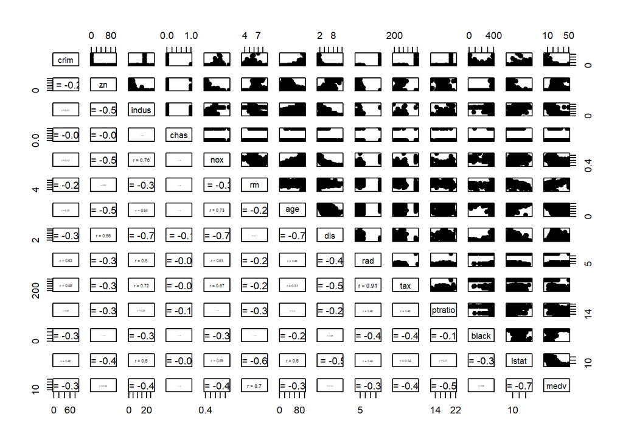

```r
# (c)
# Add correlation coefficients
# Correlation panel
panel.cor <- function(x, y){
  usr <- par("usr"); on.exit(par(usr))
  par(usr = c(0, 1, 0, 1))
  r <- round(cor(x, y), digits=2)
  txt <- paste0("r = ", r)
  cex.cor <- 0.8/strwidth(txt)
  text(0.5, 0.5, txt, cex = cex.cor * r)
}
# Customize upper panel
upper.panel<-function(x, y){
  points(x,y, pch = 19)
}
# Create the plots
pairs(Boston,
      lower.panel = panel.cor,
      upper.panel = upper.panel)
```

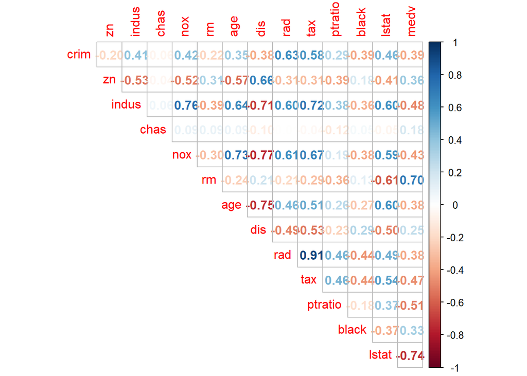

```r
# A nicer plot  using the corrplot package.
#install.packages("corrplot")
library(corrplot)
#checking correlation between variables
corrplot(cor(Boston), method = "number", type = "upper", diag = FALSE)
```

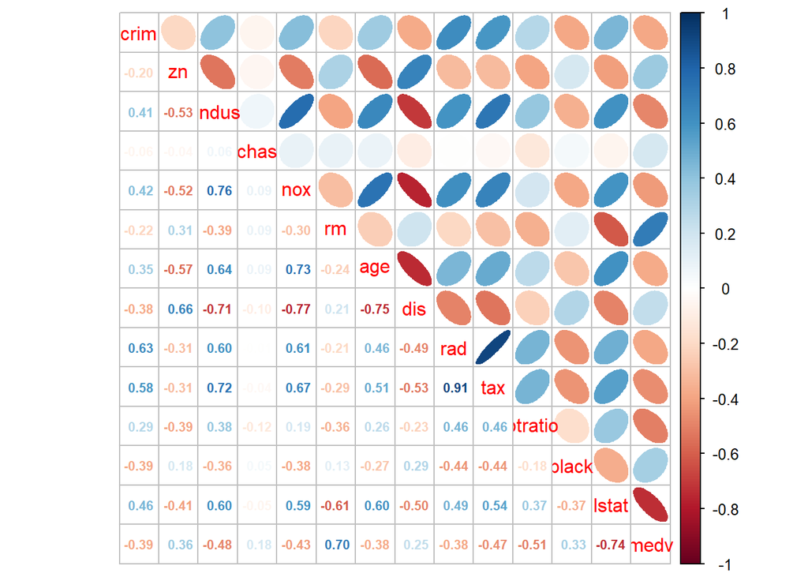

```r
corrplot.mixed(cor(Boston), upper = "ellipse", lower = "number",number.cex = .7)
```

$~$

# 2 Simple Linear Regression

This section is based on Lab 3.6, pages 109-119, from the ISL book. For more information, see Lab 5 or Linear regression.

## 2.1 Linear regression model fitting

1. Use the `lm()` function to fit a simple linear regression model, with `medv` as the response variable and `lstat` as the predictor variable. Save the result of the regression function to `reg1`.
2. Use `summary(reg1)` command to get information about the model. This gives us the estimated coefficients, t-tests, p-values and standard errors as well as the R-square and F-statistic for the model.
3. Use `names(reg1)` function to find what types of information are stored in `reg1`. For example, we can get or extract the estimated coefficients using the function `coef(reg1)` or `reg1$coefficients`.

**Click for solution**

```r
## SOLUTION
# (a)
reg1 <- lm(medv~lstat,data=Boston)

# (b)
summary(reg1)
```

```
##
## Call:
## lm(formula = medv ~ lstat, data = Boston)
##
## Residuals:
##     Min      1Q  Median      3Q     Max
## -15.168  -3.990  -1.318   2.034  24.500
##
## Coefficients:
##             Estimate Std. Error t value Pr(>|t|)
## (Intercept) 34.55384    0.56263   61.41   <2e-16 ***
## lstat       -0.95005    0.03873  -24.53   <2e-16 ***
## ---
## Signif. codes:  0 '***' 0.001 '**' 0.01 '*' 0.05 '.' 0.1 ' ' 1
##
## Residual standard error: 6.216 on 504 degrees of freedom
## Multiple R-squared:  0.5441, Adjusted R-squared:  0.5432
## F-statistic: 601.6 on 1 and 504 DF,  p-value: < 2.2e-16
```

```r
# (c)
names(reg1)
```

```
##  [1] "coefficients"  "residuals"     "effects"       "rank"
##  [5] "fitted.values" "assign"        "qr"            "df.residual"
##  [9] "xlevels"       "call"          "terms"         "model"
```

```r
coef(reg1)
```

```
## (Intercept)       lstat
##  34.5538409  -0.9500494
```

```r
reg1$coefficients
```

```
## (Intercept)       lstat
##  34.5538409  -0.9500494
```

$~$

## 2.2 Confidence and prediction intervals

1. Obtain a 95% confidence interval for the coefficient estimates. *Hint*: use the `confint()` command.
2. Obtain a 95% confidence and prediction intervals of `medv` for a given value of `lstat`. Assume this given value of `lstat` is equal to 10.

**Click for solution**

```r
## SOLUTION
# (a)
confint(reg1, level = 0.95)
```

```
##                 2.5 %     97.5 %
## (Intercept) 33.448457 35.6592247
## lstat       -1.026148 -0.8739505
```

```r
# (b)
newdata= data.frame(lstat=10)
predict(reg1,newdata=newdata, interval="confidence",  level = 0.95)
```

```
##        fit      lwr      upr
## 1 25.05335 24.47413 25.63256
```

```r
predict(reg1,data.frame(lstat=10), interval="prediction",  level = 0.95)
```

```
##        fit      lwr      upr
## 1 25.05335 12.82763 37.27907
```

$~$

## 2.3 Regression diagnostics

1. Create a scatterplot of `lstat` and `medv`. Is there a relationship between the two variables?
2. Plot `medv` and `lstat` along with the least squares regression line using the `plot()` and `abline()` functions.
3. Use residual plots to check the assumptions of the model.

**Click for solution**

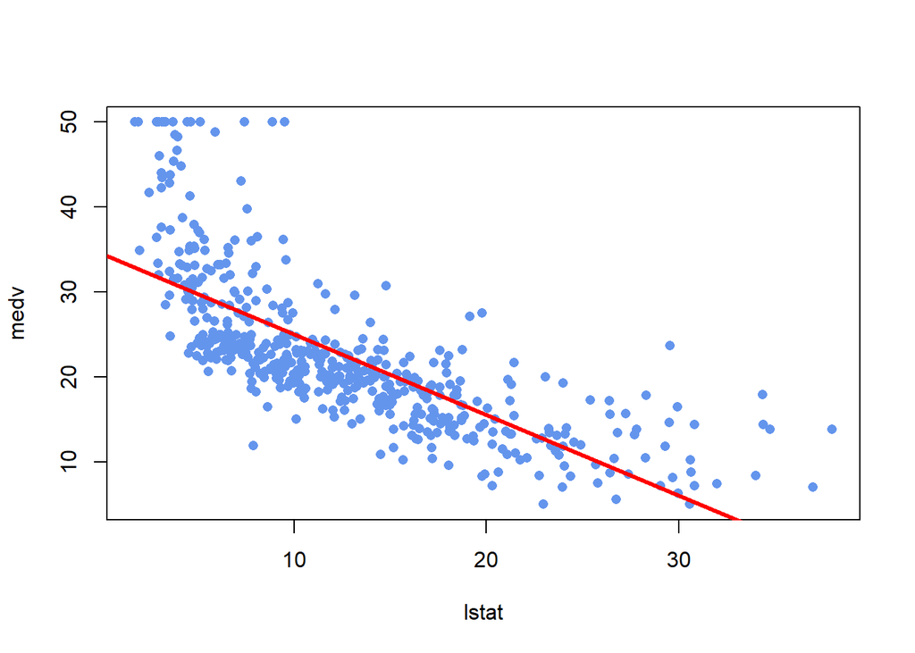

```r
## SOLUTION
# (a) & (b)
plot(lstat,medv, pch=16, col="cornflowerblue")
abline(reg1,lwd=3,col="red")
```

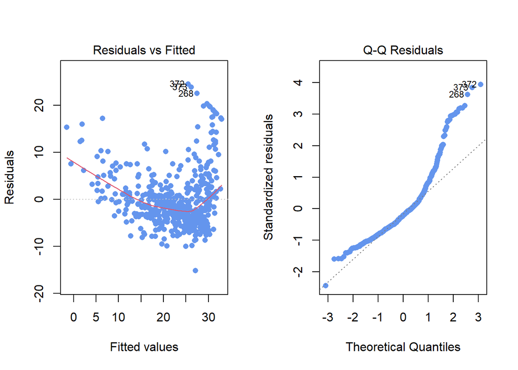

```r
# (c)
par(mfrow=c(1,2)) # to have two plots side-by-side
plot(reg1, which=1,  pch=16, col="cornflowerblue")
plot(reg1, which=2,  pch=16, col="cornflowerblue")
```

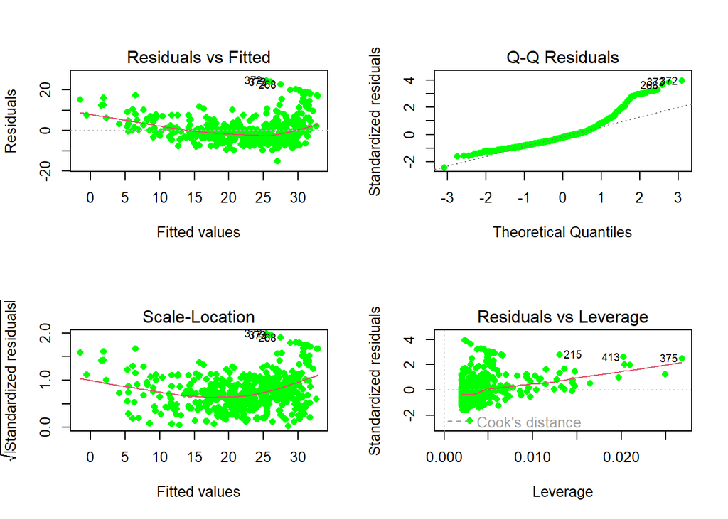

```r
par(mfrow=c(1,1)) # to return to one plot per window

par(mfrow=c(2,2))
plot(reg1,   pch=16, col="green")
```

```r
par(mfrow=c(1,1))
```

$~$

# 3 Multiple Linear Regression

## 3.1 Linear regression model fitting

1. Use the `lm()` function again to fit a linear regression model, with `medv` as the response variable and both `lstat` and `age` as predictors. Save the result of the regression function to `reg2`.
2. Now use the `lm()` function again to fit a linear regression model, with `medv` as the response variable and all other 13 variables as predictors. Save the result of the regression function to `reg3`. *Hint*: Use `lm(medv~., data=Boston)`.
3. Fit the same linear regression as in (b) but now exclude the age. Save the result of the regression function to `reg4`. *Hint*: Use `lm(medv~.-age, data=Boston)`.
4. Compare the R-squares of these models. Notice we can extract the R-square value from the summary object as `summary(reg)$r.sq`. Type `?summary.lm` to see what else is available.
5. Use Variance Inflation Factor (VIF) to assess if there is any relationship between the independent variables. *Hint*: use the `vif()` function from the `car` package.

**Click for solution**

```r
## SOLUTION
# (a)
reg2 <- lm(medv~lstat+age,data=Boston)
summary(reg2)
```

```
##
## Call:
## lm(formula = medv ~ lstat + age, data = Boston)
##
## Residuals:
##     Min      1Q  Median      3Q     Max
## -15.981  -3.978  -1.283   1.968  23.158
##
## Coefficients:
##             Estimate Std. Error t value Pr(>|t|)
## (Intercept) 33.22276    0.73085  45.458  < 2e-16 ***
## lstat       -1.03207    0.04819 -21.416  < 2e-16 ***
## age          0.03454    0.01223   2.826  0.00491 **
## ---
## Signif. codes:  0 '***' 0.001 '**' 0.01 '*' 0.05 '.' 0.1 ' ' 1
##
## Residual standard error: 6.173 on 503 degrees of freedom
## Multiple R-squared:  0.5513, Adjusted R-squared:  0.5495
## F-statistic:   309 on 2 and 503 DF,  p-value: < 2.2e-16
```

```r
# (b)
reg3 <- lm(medv~.,data=Boston)
summary(reg3)
```

```
##
## Call:
## lm(formula = medv ~ ., data = Boston)
##
## Residuals:
##     Min      1Q  Median      3Q     Max
## -15.595  -2.730  -0.518   1.777  26.199
##
## Coefficients:
##               Estimate Std. Error t value Pr(>|t|)
## (Intercept)  3.646e+01  5.103e+00   7.144 3.28e-12 ***
## crim        -1.080e-01  3.286e-02  -3.287 0.001087 **
## zn           4.642e-02  1.373e-02   3.382 0.000778 ***
## indus        2.056e-02  6.150e-02   0.334 0.738288
## chas         2.687e+00  8.616e-01   3.118 0.001925 **
## nox         -1.777e+01  3.820e+00  -4.651 4.25e-06 ***
## rm           3.810e+00  4.179e-01   9.116  < 2e-16 ***
## age          6.922e-04  1.321e-02   0.052 0.958229
## dis         -1.476e+00  1.995e-01  -7.398 6.01e-13 ***
## rad          3.060e-01  6.635e-02   4.613 5.07e-06 ***
## tax         -1.233e-02  3.760e-03  -3.280 0.001112 **
## ptratio     -9.527e-01  1.308e-01  -7.283 1.31e-12 ***
## black        9.312e-03  2.686e-03   3.467 0.000573 ***
## lstat       -5.248e-01  5.072e-02 -10.347  < 2e-16 ***
## ---
## Signif. codes:  0 '***' 0.001 '**' 0.01 '*' 0.05 '.' 0.1 ' ' 1
##
## Residual standard error: 4.745 on 492 degrees of freedom
## Multiple R-squared:  0.7406, Adjusted R-squared:  0.7338
## F-statistic: 108.1 on 13 and 492 DF,  p-value: < 2.2e-16
```

```r
# (c)
reg4 <- lm(medv~.-age,data=Boston)
summary(reg4)
```

```
##
## Call:
## lm(formula = medv ~ . - age, data = Boston)
##
## Residuals:
##      Min       1Q   Median       3Q      Max
## -15.6054  -2.7313  -0.5188   1.7601  26.2243
##
## Coefficients:
##               Estimate Std. Error t value Pr(>|t|)
## (Intercept)  36.436927   5.080119   7.172 2.72e-12 ***
## crim         -0.108006   0.032832  -3.290 0.001075 **
## zn            0.046334   0.013613   3.404 0.000719 ***
## indus         0.020562   0.061433   0.335 0.737989
## chas          2.689026   0.859598   3.128 0.001863 **
## nox         -17.713540   3.679308  -4.814 1.97e-06 ***
## rm            3.814394   0.408480   9.338  < 2e-16 ***
## dis          -1.478612   0.190611  -7.757 5.03e-14 ***
## rad           0.305786   0.066089   4.627 4.75e-06 ***
## tax          -0.012329   0.003755  -3.283 0.001099 **
## ptratio      -0.952211   0.130294  -7.308 1.10e-12 ***
## black         0.009321   0.002678   3.481 0.000544 ***
## lstat        -0.523852   0.047625 -10.999  < 2e-16 ***
## ---
## Signif. codes:  0 '***' 0.001 '**' 0.01 '*' 0.05 '.' 0.1 ' ' 1
##
## Residual standard error: 4.74 on 493 degrees of freedom
## Multiple R-squared:  0.7406, Adjusted R-squared:  0.7343
## F-statistic: 117.3 on 12 and 493 DF,  p-value: < 2.2e-16
```

```r
# (d)
summary(reg1)$r.sq
```

```
## [1] 0.5441463
```

```r
summary(reg2)$r.sq
```

```
## [1] 0.5512689
```

```r
summary(reg3)$r.sq
```

```
## [1] 0.7406427
```

```r
summary(reg4)$r.sq
```

```
## [1] 0.7406412
```

```r
summary(reg4)$r.squared
```

```
## [1] 0.7406412
```

```r
# or the adjusted R Squared
summary(reg4)$adj.r.squared
```

```
## [1] 0.7343282
```

```r
# (e)
#install.packages("car") # you need to do this once
library(car)
vif(reg3)
```

```
##     crim       zn    indus     chas      nox       rm      age      dis
## 1.792192 2.298758 3.991596 1.073995 4.393720 1.933744 3.100826 3.955945
##      rad      tax  ptratio    black    lstat
## 7.484496 9.008554 1.799084 1.348521 2.941491
```

$~$

**If you have time left, you can try the following:**

$~$

## 3.2 Interaction between variables

It is straightforward to include the interaction between variables in the linear model using the `lm()` function. For example, the syntax `lstat*age` will include `lstat`, `age` and the interaction term `lstat x age` as predictors.

```r
summary(lm(medv~lstat*age, data=Boston))
```

```
##
## Call:
## lm(formula = medv ~ lstat * age, data = Boston)
##
## Residuals:
##     Min      1Q  Median      3Q     Max
## -15.806  -4.045  -1.333   2.085  27.552
##
## Coefficients:
##               Estimate Std. Error t value Pr(>|t|)
## (Intercept) 36.0885359  1.4698355  24.553  < 2e-16 ***
## lstat       -1.3921168  0.1674555  -8.313 8.78e-16 ***
## age         -0.0007209  0.0198792  -0.036   0.9711
## lstat:age    0.0041560  0.0018518   2.244   0.0252 *
## ---
## Signif. codes:  0 '***' 0.001 '**' 0.01 '*' 0.05 '.' 0.1 ' ' 1
##
## Residual standard error: 6.149 on 502 degrees of freedom
## Multiple R-squared:  0.5557, Adjusted R-squared:  0.5531
## F-statistic: 209.3 on 3 and 502 DF,  p-value: < 2.2e-16
```

We can also include a non-linear transformation of the predictors, using the function `I()`. For example, we can regress the response variable `medv` on both `lstat` and `lstat^2` as follows.

```r
summary(lm(medv~lstat+I(lstat^2), data=Boston))
```

```
##
## Call:
## lm(formula = medv ~ lstat + I(lstat^2), data = Boston)
##
## Residuals:
##      Min       1Q   Median       3Q      Max
## -15.2834  -3.8313  -0.5295   2.3095  25.4148
##
## Coefficients:
##              Estimate Std. Error t value Pr(>|t|)
## (Intercept) 42.862007   0.872084   49.15   <2e-16 ***
## lstat       -2.332821   0.123803  -18.84   <2e-16 ***
## I(lstat^2)   0.043547   0.003745   11.63   <2e-16 ***
## ---
## Signif. codes:  0 '***' 0.001 '**' 0.01 '*' 0.05 '.' 0.1 ' ' 1
##
## Residual standard error: 5.524 on 503 degrees of freedom
## Multiple R-squared:  0.6407, Adjusted R-squared:  0.6393
## F-statistic: 448.5 on 2 and 503 DF,  p-value: < 2.2e-16
```

If we are interested in a higher-order polynomial then it is best to use the `poly()` function within the `lm()` function. For example, we use the command below if we are interested in the fifth-order polynomial fit of the `lstat`, where again the `medv` is the response variable.

```r
summary(lm(medv~poly(lstat,5), data=Boston))
```

```
##
## Call:
## lm(formula = medv ~ poly(lstat, 5), data = Boston)
##
## Residuals:
##      Min       1Q   Median       3Q      Max
## -13.5433  -3.1039  -0.7052   2.0844  27.1153
##
## Coefficients:
##                  Estimate Std. Error t value Pr(>|t|)
## (Intercept)       22.5328     0.2318  97.197  < 2e-16 ***
## poly(lstat, 5)1 -152.4595     5.2148 -29.236  < 2e-16 ***
## poly(lstat, 5)2   64.2272     5.2148  12.316  < 2e-16 ***
## poly(lstat, 5)3  -27.0511     5.2148  -5.187 3.10e-07 ***
## poly(lstat, 5)4   25.4517     5.2148   4.881 1.42e-06 ***
## poly(lstat, 5)5  -19.2524     5.2148  -3.692 0.000247 ***
## ---
## Signif. codes:  0 '***' 0.001 '**' 0.01 '*' 0.05 '.' 0.1 ' ' 1
##
## Residual standard error: 5.215 on 500 degrees of freedom
## Multiple R-squared:  0.6817, Adjusted R-squared:  0.6785
## F-statistic: 214.2 on 5 and 500 DF,  p-value: < 2.2e-16
```

Finally, we can also apply other transformations, e.g. taking the log of `rm` (average number of rooms per dwelling).

```r
summary(lm(medv~log(rm), data=Boston))
```

```
##
## Call:
## lm(formula = medv ~ log(rm), data = Boston)
##
## Residuals:
##     Min      1Q  Median      3Q     Max
## -19.487  -2.875  -0.104   2.837  39.816
##
## Coefficients:
##             Estimate Std. Error t value Pr(>|t|)
## (Intercept)  -76.488      5.028  -15.21   <2e-16 ***
## log(rm)       54.055      2.739   19.73   <2e-16 ***
## ---
## Signif. codes:  0 '***' 0.001 '**' 0.01 '*' 0.05 '.' 0.1 ' ' 1
##
## Residual standard error: 6.915 on 504 degrees of freedom
## Multiple R-squared:  0.4358, Adjusted R-squared:  0.4347
## F-statistic: 389.3 on 1 and 504 DF,  p-value: < 2.2e-16
```

$~$